# Data Analysis: Obesity Prevalence

# 1 Introduction

Obesity is a significant public health concern, influenced by various socio-economic and lifestyle factors. This analysis uses data from the 2008-2012 Scottish Health Surveys to explore the relationship between demographic variables, lifestyle habits, and obesity prevalence in Scotland. The dataset includes information on age, gender, employment, dietary habits, and obesity status.

The objective is to examine trends in obesity prevalence over the survey years and identify differences in obesity rates based on socio-economic and lifestyle factors. The findings will inform public health strategies aimed at addressing obesity.

Section 2 provides an exploratory analysis of the dataset, including trends in obesity across different groups. Section 3 presents the results of a regression analysis, including model diagnostics to assess the model’s fit and assumptions. Concluding remarks are in Section 4.

# 2 Exploratory data analysis

## 2.1 Distribution of each variable

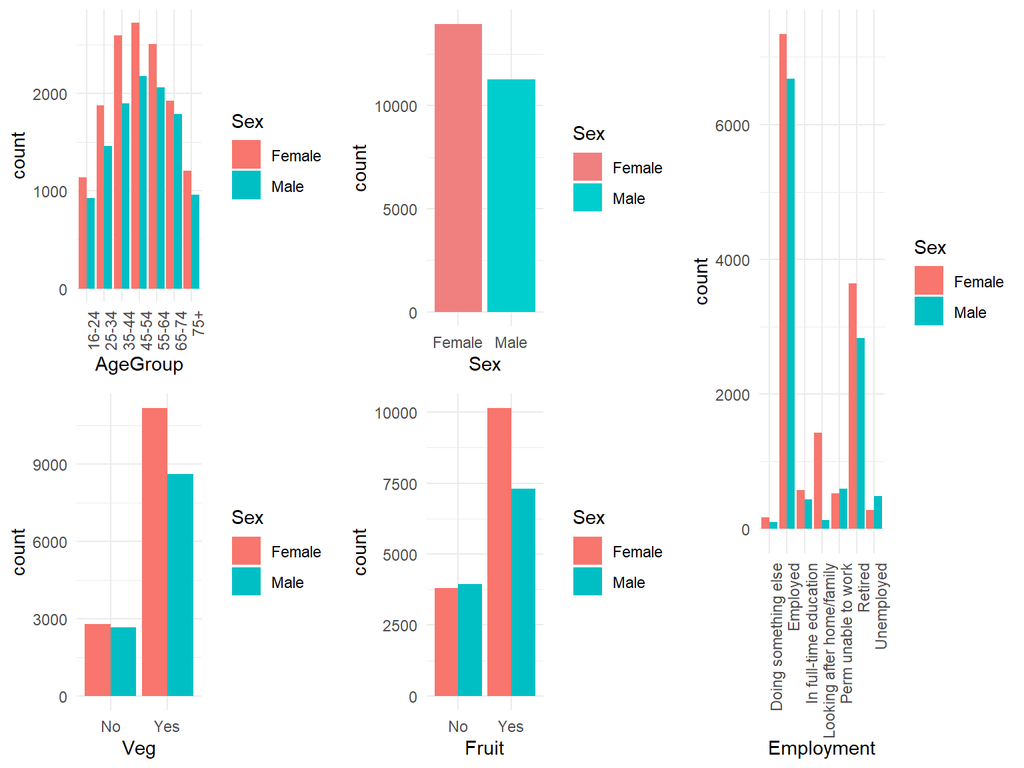

Figure 1: Distribution of Age Group, Employment Status, Vegetable Consumption, Fruit Consumption, and Sex by Gender in the Dataset.

## 2.2 Obesity changes over time (2008-2012)

Table 1 presents the yearly obesity rates in Scotland between 2008 and 2012. Overall, the obesity rate dropped to its lowest point in 2009 (28.79%), and then rose sharply in 2010, reaching its highest point in five years (30.47%). After that, the obesity rate fell back and stabilized in 2011-2012. The data shows that there were some fluctuations in the obesity rate during this period, but it generally remained between 29% and 30.5%.

Table 1: Yearly Obesity Rate in Scotland from 2008 to 2012.

Yearly Obesity Rate (2008-2012)

| Year | ObesityRate |
| --- | --- |
| 2008 | 29.57 |
| 2009 | 28.79 |
| 2010 | 30.47 |
| 2011 | 29.65 |
| 2012 | 29.61 |

## 2.3 Obesity trend over time (2008-2012)

Figure 2 shows the yearly trend of obesity rate in Scotland from 2008 to 2012. The trend shows that after the obesity rate fell in 2009, it rose significantly in 2010, and then gradually fell back and stabilized. The fluctuation in 2010 may reflect the increase in health risk factors that year, while the slowdown after 2011 may be related to health intervention measures and the improvement of awareness of physiological health management. Overall, the obesity rate shows periodic fluctuations but remains at a relatively high level.

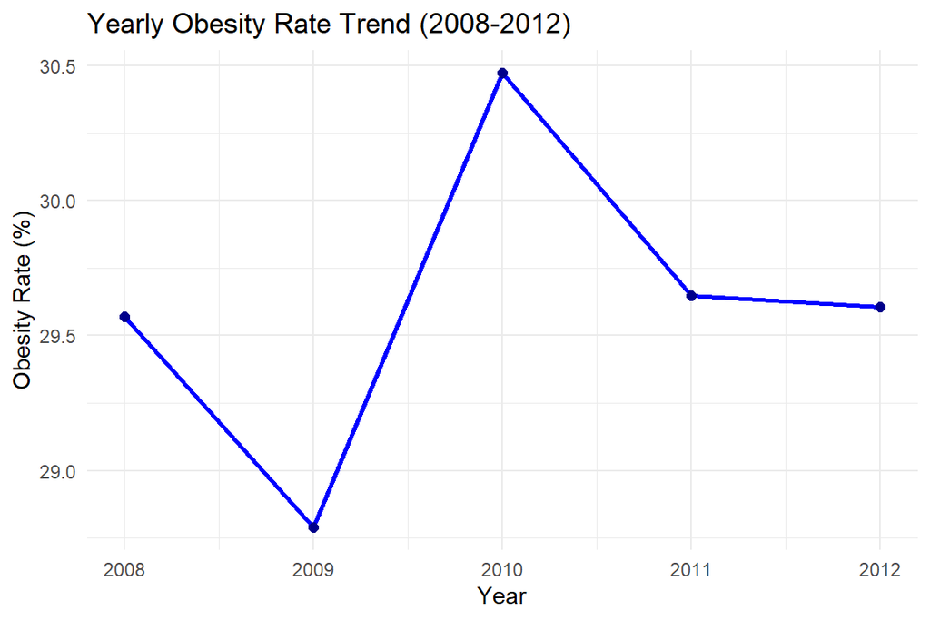

Figure 2: Yearly Obesity Rate Trend in Scotland (2008-2012)

## 2.4 Group-wise Obesity Rate Analysis

In this section, we explore the obesity rates by various grouping variables (Age Group, Employment, Vegetable Intake, and Fruit Intake) stratified by Sex. The obesity rates are counted and generates Figure 3.

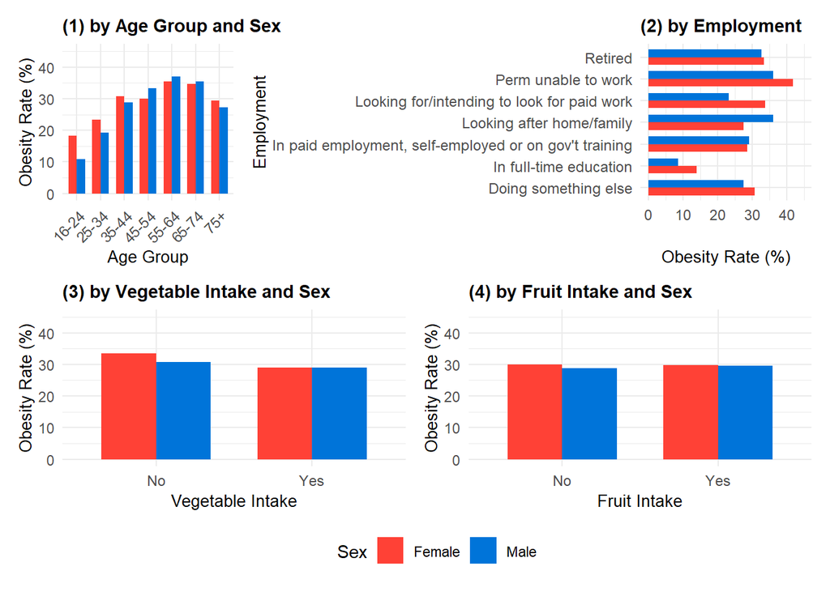

Figure 3: Obesity Rates by Demographic and Lifestyle Factors.

1. Obesity Rate by Age Group and Sex:Obesity rates increase with age, peaking at 55-64 years (36.9% males, 35.4% females), before declining in older adults. Gender differences are evident in younger age groups, with females showing higher rates, but the trend reverses slightly in middle age, indicating that metabolic and lifestyle changes play a role.
2. Obesity Rate by Employment Status and Sex: Obesity prevalence varies by employment status, highest among those permanently unable to work (41.9% females, 36.2% males) and lowest among students (13.9% females, 8.6% males). Gender differences appear in caregiving roles and job-seeking categories, emphasizing the link between socioeconomic conditions and obesity.
3. Obesity Rate by Vegetable Intake and Sex: Higher vegetable intake is associated with lower obesity rates for both sexes, with a stronger effect in females (from 33.4% to 28.9%). This suggests a protective role of vegetable consumption against obesity, reinforcing the importance of dietary habits in obesity prevention.
4. Obesity Rate by Fruit Intake and Sex:Unlike vegetables, fruit intake shows minimal association with obesity, as obesity rates remain nearly unchanged regardless of fruit consumption (29.9% vs. 29.8% for females, 28.9% vs. 29.6% for males). This highlights potential differences in how various dietary components impact obesity.

Age shows the most consistent pattern, with employment status exhibiting the widest variation, particularly for students and those unable to work. Vegetable intake correlates with lower obesity rates, whereas fruit intake shows little impact. Gender differences vary across factors, illustrating the complexity of obesity risk.

## 2.5 Variable Relationships

In this section, we perform chi-square tests to assess the association between categorical variables and obesity status, and then compute a correlation matrix (and its heatmap) on a numeric copy of the data.

### 2.5.1 Chi-square Tests

```
    AgeGroup          Sex   Employment          Veg        Fruit
6.559210e-98 4.563809e-01 4.427490e-51 8.670466e-06 5.726165e-01
```

Age group, employment status, and vegetable intake show significant associations with obesity, while sex and fruit intake do not reach statistical significance. These findings validate previous observations and highlight key influencing factors.

### 2.5.2 Correlation Analysis

For the correlation analysis, we create a numeric copy of the data to convert categorical variables into numerical codes.

```
              AgeGroup          Sex  Employment         Veg       Fruit
AgeGroup    1.00000000 -0.019575571 0.678498481  0.07409669 0.171563984
Sex        -0.01957557  1.000000000 0.008228749  0.04357230 0.084283414
Employment  0.67849848  0.008228749 1.000000000  0.01325244 0.076353203
Veg         0.07409669  0.043572296 0.013252439  1.00000000 0.199826528
Fruit       0.17156398  0.084283414 0.076353203  0.19982653 1.000000000
Obese       0.10319082  0.004777027 0.064315456 -0.02811161 0.003646521
                  Obese
AgeGroup    0.103190818
Sex         0.004777027
Employment  0.064315456
Veg        -0.028111608
Fruit       0.003646521
Obese       1.000000000
```

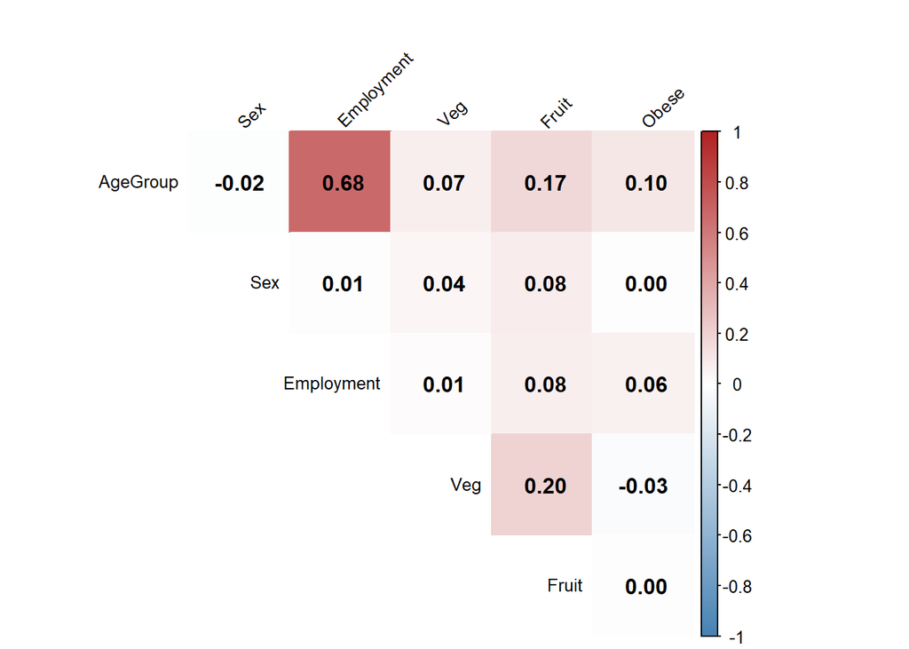

Figure 4: Correlation Heatmap.

In Figure 4, age shows the strongest correlation with obesity (r = 0.10), followed by employment status (r = 0.06), while vegetable intake is negatively correlated (r = -0.03). Sex and fruit intake exhibit near-zero correlations, aligning with chi-square results, reinforcing their weaker influence.

### 2.5.3 Potential Influencing factors

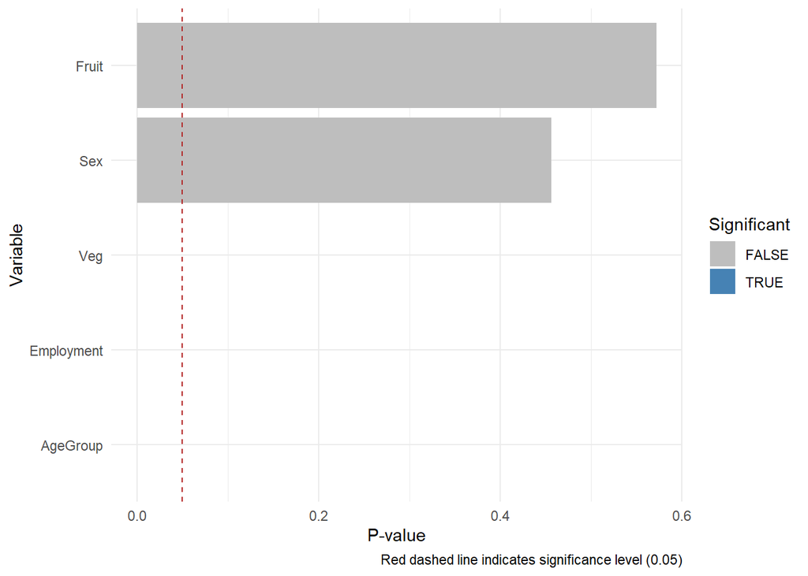

Figure 5: Chi-square Test P-values for Association with Obesity.

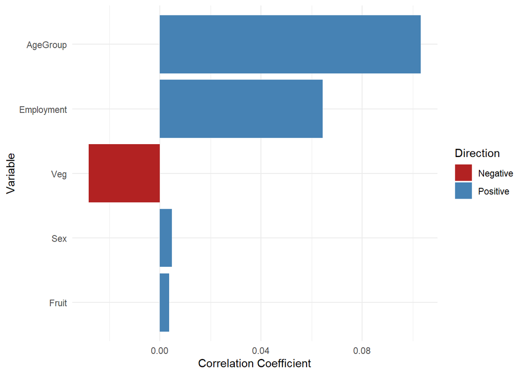

Figure 6: Correlations with Obesity Status.

Based on the Figure 5 and Figure 6, the following factors appear to have the strongest association with obesity status:

```
Significant factors (chi-square): AgeGroup, Employment, Veg
```

```
Top correlating factors: AgeGroup, Employment
```

Age emerges as the most critical factor in obesity risk, followed by employment status and vegetable intake, while sex and fruit intake show weaker associations. The interaction between age and employment suggests socioeconomic factors play a key role in obesity prevalence.

# 3 Formal Data Analysis

## 3.1 Variable Selection & Regression Modelling

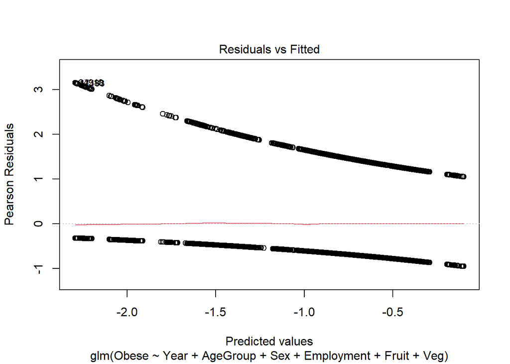

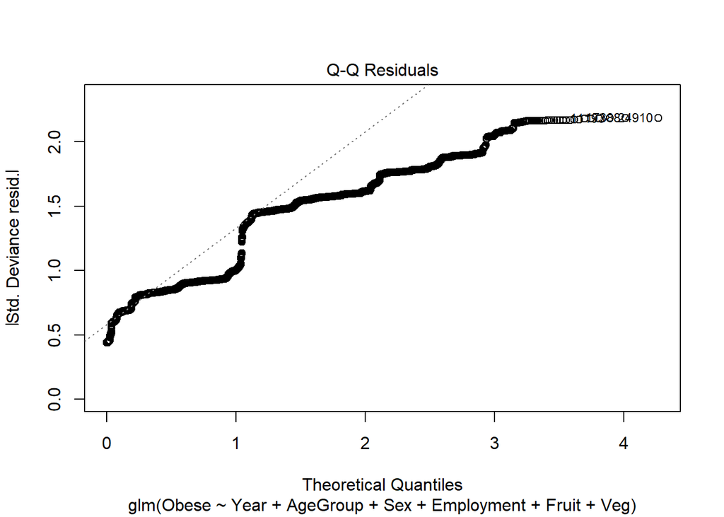

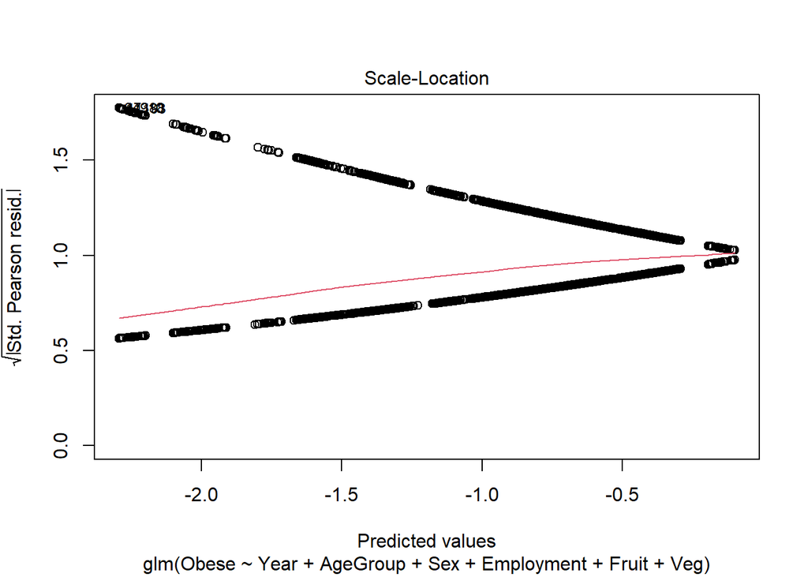

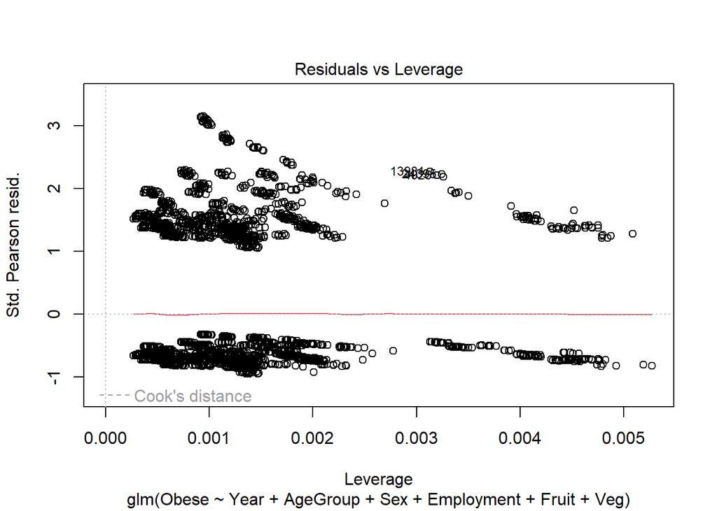

```
[1] 0.3379382 0.2824812 0.3334057 0.3222281 0.2165116 0.3823853
```

```
[1] 30080.98
```

```
Start:  AIC=30080.98
Obese ~ Year + AgeGroup + Sex + Employment + Fruit + Veg

             Df Deviance   AIC
- Year        1    30047 30079
- Fruit       1    30048 30080
<none>             30047 30081
- Sex         1    30050 30082
- Veg         1    30078 30110
- Employment  6    30106 30128
- AgeGroup    6    30349 30371

Step:  AIC=30079.13
Obese ~ AgeGroup + Sex + Employment + Fruit + Veg

             Df Deviance   AIC
- Fruit       1    30048 30078
<none>             30047 30079
- Sex         1    30050 30080
+ Year        1    30047 30081
- Veg         1    30079 30109
- Employment  6    30107 30127
- AgeGroup    6    30349 30369

Step:  AIC=30078.14
Obese ~ AgeGroup + Sex + Employment + Veg

             Df Deviance   AIC
<none>             30048 30078
- Sex         1    30051 30079
+ Fruit       1    30047 30079
+ Year        1    30048 30080
- Veg         1    30083 30111
- Employment  6    30109 30127
- AgeGroup    6    30349 30367
```

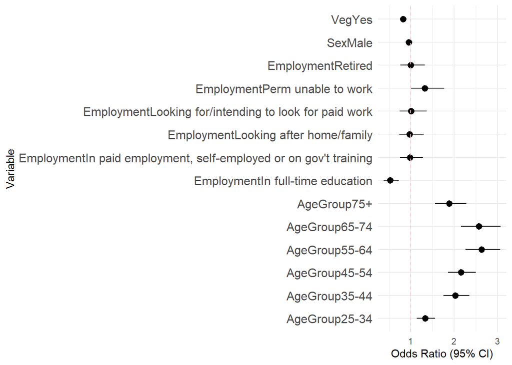

| Coefficients | Estimate | Std. Error | z value | Pr(>\|z\|) |
| --- | --- | --- | --- | --- |
| (Intercept) | -9.4455065 | 20.9773716 | -0.450 | 0.652515 |
| Year | 0.0040207 | 0.0104345 | 0.385 | 0.699993 |
| AgeGroup: 25-34 | 0.2905346 | 0.0792707 | 3.665 | 0.000247 *** |
| AgeGroup: 35-44 | 0.7118661 | 0.0755078 | 9.428 | < 2e-16 *** |
| AgeGroup: 45-54 | 0.7732339 | 0.0752725 | 10.272 | < 2e-16 *** |
| AgeGroup: 55-64 | 0.9751481 | 0.0771905 | 12.633 | < 2e-16 *** |
| AgeGroup: 65-74 | 0.9536306 | 0.0898307 | 10.616 | < 2e-16 *** |
| AgeGroup: 75+ | 0.6432094 | 0.0985387 | 6.527 | 6.69e-11 *** |
| SexMale | -0.0463063 | 0.0288692 | -1.604 | 0.108713 |
| Employment: In full-time education | -0.6499833 | 0.1710072 | -3.801 | 0.000144 *** |
| Employment: In paid employment, self-employed or on gov’t training | -0.0172654 | 0.1353190 | -0.128 | 0.898473 |
| Employment: Looking after home/family | -0.0278140 | 0.1456978 | -0.191 | 0.848603 |
| Employment: Looking for/intending to look for paid work | 0.0009539 | 0.1574827 | 0.006 | 0.995167 |
| Employment: Perm unable to work | 0.2800048 | 0.1476789 | 1.896 | 0.057955 |
| Employment: Retired | 0.0006616 | 0.1418566 | 0.005 | 0.996279 |
| Fruit: Yes | -0.0316488 | 0.0316202 | -1.001 | 0.316873 |
| Veg: Yes | -0.1930594 | 0.0342967 | -5.629 | 1.81e-08 *** |

## 3.2 Model Diagnostics & Evaluation

### 3.2.1 Overdispersion Check

```
# Overdispersion test

 dispersion ratio = 1.000
          p-value = 0.944
```

No Overdispersion means that the standard errors of the model’s coefficients have not been underestimated. Overdispersion can lead to type I errors

### 3.2.2 Check Outliers & Cooks Distance

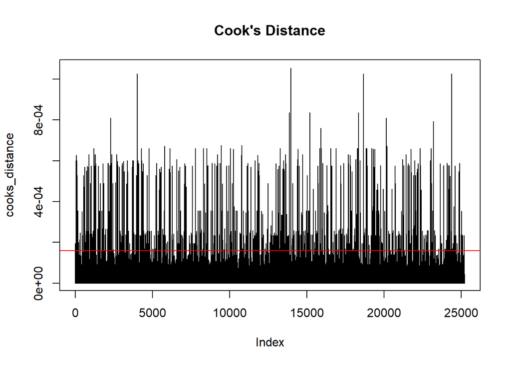